# Phylogenetic Signal and Ancestral State Reconstruction

Rene Huerta

2026-07-15

# Overview

This file demonstrates the workflow I use to analyze binary and multistate traits across a phylogeny. It follows the same general methods I used in my evolutionary research, including checking the data, removing duplicates, matching trait data to a phylogenetic tree, pruning unmatched species, calculating Fritz and Purvis’s D, fitting an all-rates-different transition model, and reconstructing ancestral states with `corHMM`.

To keep this example public and reproducible, it uses the `BritishBirds` dataset included in the `caper` package over any unpublished research data or results.

# Load packages

```r
library(geiger)
library(nlme)
library(phytools)
library(corHMM)
library(caper)
library(picante)
library(ape)
library(dplyr)
library(knitr)
```

# Load the public data and phylogenetic tree

```r
data("BritishBirds", package = "caper")

birdData <- BritishBirds.data
birdPhy <- BritishBirds.tree
```

```r
cat("Rows in the original trait dataset:", nrow(birdData), "\n")
```

```
## Rows in the original trait dataset: 181
```

```r
cat("Columns in the original trait dataset:", ncol(birdData), "\n")
```

```
## Columns in the original trait dataset: 26
```

```r
cat("Tips in the original phylogeny:", length(birdPhy$tip.label), "\n")
```

```
## Tips in the original phylogeny: 250
```

```r
head(
  birdData[, c(
    "binomial",
    "common_name",
    "Red_list",
    "Amber_list",
    "Green_list"
  )]
)
```

```
##                        binomial         common_name Red_list Amber_list
## 1        Acrocephalus.palustris       Marsh_warbler        1          0
## 2 Coccothraustes.coccothraustes            hawfinch        0          1
## 3             Emberiza.calandra        Corn_bunting        1          0
## 4             Locustella.naevia Grasshopper_warbler        1          0
## 5         Luscinia.megarhynchos  rufous_nightingale        0          1
## 6              Rallus.aquaticus          water_rail        0          1
##   Green_list
## 1          0
## 2          0
## 3          0
## 4          0
## 5          0
## 6          0
```

# Select the species and binary-trait columns

In my original workflow, I selected a defined range of morphology columns. For this public example, I keep the species identifier and three binary conservation-status traits.

```r
traitColumns <- c(
  "binomial",
  "Red_list",
  "Amber_list",
  "Green_list"
)

birdBinaryData <- birdData[, traitColumns]
```

# Remove empty species rows

The original dataset I worked with contained extra empty rows at the end of the CSV file. This dataset does not normally include those rows, but I keep the same check so the workflow can handle them if they appear.

```r
validSpeciesRows <- !is.na(birdBinaryData$binomial) &
  trimws(birdBinaryData$binomial) != ""

birdBinaryData <- birdBinaryData[validSpeciesRows, ]
```

# Check for duplicate rows

```r
birdDuplicates <- birdBinaryData[
  duplicated(birdBinaryData) |
    duplicated(birdBinaryData, fromLast = TRUE),
]

birdDuplicates
```

```
## [1] binomial   Red_list   Amber_list Green_list
## <0 rows> (or 0-length row.names)
```

# Remove node labels

```r
birdPhy$node.label <- NULL
```

# Remove duplicate species

```r
birdBinaryDataNoDup <- birdBinaryData[
  !duplicated(birdBinaryData$binomial),
]
```

# Set row names to species names

`match.phylo.data()` matches tree tips to the row names of the trait dataset, so I set the row names using each species’ binomial name.

```r
rownames(birdBinaryDataNoDup) <- birdBinaryDataNoDup$binomial
```

# Remove missing observations

As in my original workflow, I use `na.omit()` before matching the data and tree so every retained species has values for all selected traits.

```r
birdBinaryDataNoDup <- na.omit(birdBinaryDataNoDup)
```

# Match the phylogeny and trait data

```r
invisible(
  capture.output({
    birdMatchedData <- match.phylo.data(
      birdPhy,
      birdBinaryDataNoDup
    )
  })
)

birdPrunedPhy <- birdMatchedData$phy
birdPrunedBinaryData <- birdMatchedData$data
```

# Convert binary traits to integers

```r
birdPrunedBinaryData <- birdPrunedBinaryData %>%
  mutate(
    across(
      -binomial,
      as.integer
    )
  )
```

# Check the matched phylogeny

```r
if (any(duplicated(birdPrunedPhy$tip.label))) {
  stop("Duplicate tip labels found in the phylogeny.")
}
```

```r
if (!is.null(birdPrunedPhy$node.label)) {
  birdPrunedPhy$node.label <- make.unique(
    as.character(birdPrunedPhy$node.label)
  )
}
```

# Create the comparative data object

```r
birdComparativeData <- comparative.data(
  phy = birdPrunedPhy,
  data = birdPrunedBinaryData,
  names.col = "binomial",
  vcv = FALSE,
  na.omit = FALSE,
  warn.dropped = TRUE
)

print(birdComparativeData)
```

```
## Comparative dataset of 181 taxa:
## Phylogeny: birdPrunedPhy
##    181 tips, 180 internal nodes
##    chr [1:181] "Tetrao.tetrix" "Lagopus.lagopus" "Lagopus.muta" ...
## Data: birdPrunedBinaryData
##    $ Red_list  : int [1:181] 1 0 0 1 1 0 0 0 0 1 ...
##    $ Amber_list: int [1:181] 0 1 0 0 0 1 1 1 1 0 ...
##    $ Green_list: int [1:181] 0 0 1 0 0 0 0 0 0 0 ...
```

# Plot the pruned phylogeny

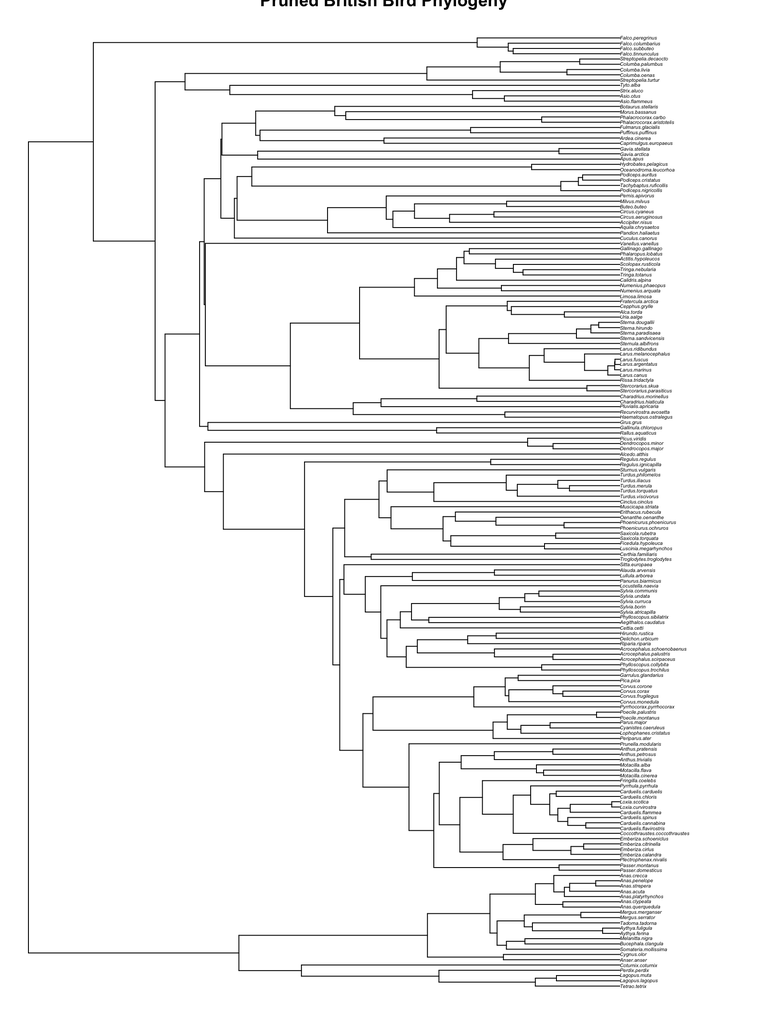

```r
plot(
  birdPrunedPhy,
  cex = 0.35,
  no.margin = TRUE,
  main = "Pruned British Bird Phylogeny"
)
```

# Calculate phylogenetic signal

Fritz and Purvis’s D compares the observed distribution of a binary trait with two reference patterns:

- A D value near 1 is consistent with a random distribution across the tree.
- A D value near 0 is consistent with clustering under a Brownian threshold model.
- Values below 0 suggest stronger clustering.
- Values above 1 suggest greater overdispersion.

The `phylo.d()` function expects an unquoted column name. Because the trait names are stored as text inside `traitList`, I build and evaluate the call inside the function.

```r
calculatePhyloD <- function(
  traitName,
  comparativeData,
  permutations = 1000
) {

  if (!traitName %in% names(comparativeData$data)) {
    stop(
      paste0(
        "'", traitName,
        "' is not present in the comparative dataset."
      )
    )
  }

  phyloDCall <- substitute(
    phylo.d(
      data = comparativeData,
      binvar = traitVariable,
      permut = permutationCount
    ),
    list(
      traitVariable = as.name(traitName),
      permutationCount = permutations
    )
  )

  phyloDResult <- eval(phyloDCall)

  data.frame(
    trait = traitName,
    dEstimate = phyloDResult$DEstimate,
    pDifferentFromRandom = phyloDResult$Pval1,
    pDifferentFromBrownian = phyloDResult$Pval0
  )
}
```

# Run phylogenetic-signal analysis for all binary traits

```r
set.seed(1)

traitList <- c(
  "Red_list",
  "Amber_list",
  "Green_list"
)

phyloDResultsList <- lapply(
  traitList,
  calculatePhyloD,
  comparativeData = birdComparativeData,
  permutations = 1000
)

phyloDResults <- bind_rows(phyloDResultsList)

kable(
  phyloDResults,
  digits = 4,
  caption = "Phylogenetic signal across binary conservation traits"
)
```

Phylogenetic signal across binary conservation traits

|  | trait | dEstimate | pDifferentFromRandom | pDifferentFromBrownian |
| --- | --- | --- | --- | --- |
| Obs…1 | Red_list | 0.5554 | 0.001 | 0.027 |
| Obs…2 | Amber_list | 0.6766 | 0.003 | 0.001 |
| Obs…3 | Green_list | 0.8553 | 0.103 | 0.000 |

# Save individual D-statistic results

The trait names are unquoted here because that is the format expected by `phylo.d()`.

```r
set.seed(1)

redListPhyloD <- phylo.d(
  birdComparativeData,
  binvar = Red_list,
  permut = 1000
)

amberListPhyloD <- phylo.d(
  birdComparativeData,
  binvar = Amber_list,
  permut = 1000
)

greenListPhyloD <- phylo.d(
  birdComparativeData,
  binvar = Green_list,
  permut = 1000
)

print(redListPhyloD)
```

```
##
## Calculation of D statistic for the phylogenetic structure of a binary variable
##
##   Data :  birdPrunedBinaryData
##   Binary variable :  Red_list
##   Counts of states:  0 = 149
##                      1 = 32
##   Phylogeny :  birdPrunedPhy
##   Number of permutations :  1000
##
## Estimated D :  0.5554448
## Probability of E(D) resulting from no (random) phylogenetic structure :  0.001
## Probability of E(D) resulting from Brownian phylogenetic structure    :  0.027
```

```r
print(amberListPhyloD)
```

```
##
## Calculation of D statistic for the phylogenetic structure of a binary variable
##
##   Data :  birdPrunedBinaryData
##   Binary variable :  Amber_list
##   Counts of states:  0 = 92
##                      1 = 89
##   Phylogeny :  birdPrunedPhy
##   Number of permutations :  1000
##
## Estimated D :  0.6765832
## Probability of E(D) resulting from no (random) phylogenetic structure :  0.003
## Probability of E(D) resulting from Brownian phylogenetic structure    :  0.001
```

```r
print(greenListPhyloD)
```

```
##
## Calculation of D statistic for the phylogenetic structure of a binary variable
##
##   Data :  birdPrunedBinaryData
##   Binary variable :  Green_list
##   Counts of states:  0 = 121
##                      1 = 60
##   Phylogeny :  birdPrunedPhy
##   Number of permutations :  1000
##
## Estimated D :  0.8553324
## Probability of E(D) resulting from no (random) phylogenetic structure :  0.103
## Probability of E(D) resulting from Brownian phylogenetic structure    :  0
```

# Combine the D estimates into a matrix

```r
combinedPhyloD <- c(
  redListPhyloD$DEstimate,
  amberListPhyloD$DEstimate,
  greenListPhyloD$DEstimate
)

phyloDMatrix <- matrix(
  combinedPhyloD,
  nrow = 1,
  byrow = TRUE,
  dimnames = list(
    "D estimate",
    c("Red list", "Amber list", "Green list")
  )
)

print(phyloDMatrix)
```

```
##             Red list Amber list Green list
## D estimate 0.5554448  0.6765832  0.8553324
```

# Create a multistate conservation-status trait

```r
statusCount <- rowSums(
  birdPrunedBinaryData[, c(
    "Red_list",
    "Amber_list",
    "Green_list"
  )]
)

if (any(statusCount != 1)) {
  stop()
}

birdPrunedBinaryData$conservationState <- case_when(
  birdPrunedBinaryData$Red_list == 1 ~ "Red",
  birdPrunedBinaryData$Amber_list == 1 ~ "Amber",
  birdPrunedBinaryData$Green_list == 1 ~ "Green",
  TRUE ~ NA_character_
)

table(birdPrunedBinaryData$conservationState)
```

```
##
## Amber Green   Red
##    89    60    32
```

# Fit an all-rates-different transition model

- **ER:** all transitions share one rate.
- **SYM:** forward and reverse transitions between each pair of states share the same rate.
- **ARD:** every directional transition can have its own rate.

```r
prunedConservationState <- setNames(
  birdPrunedBinaryData$conservationState,
  birdPrunedBinaryData$binomial
)

# Reorder the trait vector so it follows the same order as the tree tips.
prunedConservationState <- prunedConservationState[
  birdPrunedPhy$tip.label
]

# Check which states are represented after pruning.
table(prunedConservationState)
```

```
## prunedConservationState
## Amber Green   Red
##    89    60    32
```

## Equal-rates model

```r
fitMkConservationER <- fitMk(
  tree = birdPrunedPhy,
  x = prunedConservationState,
  model = "ER",
  pi = "estimated"
)
```

```
## Using pi estimated from the stationary distribution of Q assuming a flat prior.
## pi =
##    Amber    Green      Red
## 0.333333 0.333333 0.333333
```

```r
print(fitMkConservationER)
```

```
## Object of class "fitMk".
##
## Fitted (or set) value of Q:
##           Amber     Green       Red
## Amber -3.103638  1.551819  1.551819
## Green  1.551819 -3.103638  1.551819
## Red    1.551819  1.551819 -3.103638
##
## Fitted (or set) value of pi:
##    Amber    Green      Red
## 0.333333 0.333333 0.333333
## due to treating the root prior as (a) stationary.
##
## Log-likelihood: -198.844171
##
## Optimization method used was "nlminb"
##
## R thinks it has found the ML solution.
```

## Symmetric-rates model

```r
fitMkConservationSYM <- fitMk(
  tree = birdPrunedPhy,
  x = prunedConservationState,
  model = "SYM",
  pi = "estimated"
)
```

```
## Using pi estimated from the stationary distribution of Q assuming a flat prior.
## pi =
##    Amber    Green      Red
## 0.333333 0.333333 0.333333
```

```r
print(fitMkConservationSYM)
```

```
## Object of class "fitMk".
##
## Fitted (or set) value of Q:
##           Amber     Green       Red
## Amber -0.059941  0.059941  0.000000
## Green  0.059941 -0.096715  0.036774
## Red    0.000000  0.036774 -0.036774
##
## Fitted (or set) value of pi:
##    Amber    Green      Red
## 0.333333 0.333333 0.333333
## due to treating the root prior as (a) stationary.
##
## Log-likelihood: -184.261053
##
## Optimization method used was "nlminb"
##
## R thinks it has found the ML solution.
```

## All-rates-different model

```r
fitMkConservationARD <- fitMk(
  tree = birdPrunedPhy,
  x = prunedConservationState,
  model = "ARD",
  pi = "estimated"
)
```

```
## Using pi estimated from the stationary distribution of Q assuming a flat prior.
## pi =
##    Amber    Green      Red
## 0.522539 0.319510 0.157951
```

```r
print(fitMkConservationARD)
```

```
## Object of class "fitMk".
##
## Fitted (or set) value of Q:
##           Amber     Green       Red
## Amber -0.063597  0.063597  0.000000
## Green  0.103561 -0.172244  0.068683
## Red    0.000000  0.138284 -0.138284
##
## Fitted (or set) value of pi:
##    Amber    Green      Red
## 0.522539 0.319510 0.157951
## due to treating the root prior as (a) stationary.
##
## Log-likelihood: -179.851286
##
## Optimization method used was "nlminb"
##
## R thinks it has found the ML solution.
```

# Compare model support

I compare the models using AIC and sample-size-corrected AIC, or AICc. The model with the lowest value has the strongest relative support among the models compared.

```r
extractModelMetrics <- function(
  fittedModel,
  modelName,
  sampleSize
) {

  if (is.null(fittedModel)) {
    return(
      data.frame(
        model = modelName,
        logLikelihood = NA_real_,
        parameterCount = NA_integer_,
        aic = NA_real_,
        aicc = NA_real_
      )
    )
  }

  logLikelihood <- as.numeric(logLik(fittedModel))
  parameterCount <- attr(logLik(fittedModel), "df")

  modelAIC <- AIC(fittedModel)

  modelAICc <- modelAIC +
    (
      2 * parameterCount * (parameterCount + 1)
    ) /
    (
      sampleSize - parameterCount - 1
    )

  data.frame(
    model = modelName,
    logLikelihood = logLikelihood,
    parameterCount = parameterCount,
    aic = modelAIC,
    aicc = modelAICc
  )
}

sampleSize <- length(prunedConservationState)

transitionModelResults <- bind_rows(
  extractModelMetrics(
    fitMkConservationER,
    "ER",
    sampleSize
  ),
  extractModelMetrics(
    fitMkConservationSYM,
    "SYM",
    sampleSize
  ),
  extractModelMetrics(
    fitMkConservationARD,
    "ARD",
    sampleSize
  )
)

transitionModelResults <- transitionModelResults %>%
  filter(!is.na(aicc)) %>%
  arrange(aicc) %>%
  mutate(
    deltaAIC = aic - min(aic),
    deltaAICc = aicc - min(aicc),
    aiccWeight = exp(-0.5 * deltaAICc) /
      sum(exp(-0.5 * deltaAICc))
  )

kable(
  transitionModelResults,
  digits = 4,
  caption = "Comparison of discrete-trait transition models"
)
```

Comparison of discrete-trait transition models

| model | logLikelihood | parameterCount | aic | aicc | deltaAIC | deltaAICc | aiccWeight |
| --- | --- | --- | --- | --- | --- | --- | --- |
| ARD | -179.8513 | 6 | 371.7026 | 372.1853 | 0.0000 | 0.0000 | 0.7749 |
| SYM | -184.2611 | 3 | 374.5221 | 374.6577 | 2.8195 | 2.4724 | 0.2251 |
| ER | -198.8442 | 1 | 399.6883 | 399.7107 | 27.9858 | 27.5254 | 0.0000 |

# Select the best-supported model

```r
bestModelName <- transitionModelResults$model[1]

bestTransitionModel <- switch(
  bestModelName,
  "ER" = fitMkConservationER,
  "SYM" = fitMkConservationSYM,
  "ARD" = fitMkConservationARD
)

cat(
  "Best-supported model based on AICc:",
  bestModelName,
  "\n"
)
```

```
## Best-supported model based on AICc: ARD
```

```r
print(bestTransitionModel)
```

```
## Object of class "fitMk".
##
## Fitted (or set) value of Q:
##           Amber     Green       Red
## Amber -0.063597  0.063597  0.000000
## Green  0.103561 -0.172244  0.068683
## Red    0.000000  0.138284 -0.138284
##
## Fitted (or set) value of pi:
##    Amber    Green      Red
## 0.522539 0.319510 0.157951
## due to treating the root prior as (a) stationary.
##
## Log-likelihood: -179.851286
##
## Optimization method used was "nlminb"
##
## R thinks it has found the ML solution.
```

# Plot all fitted models

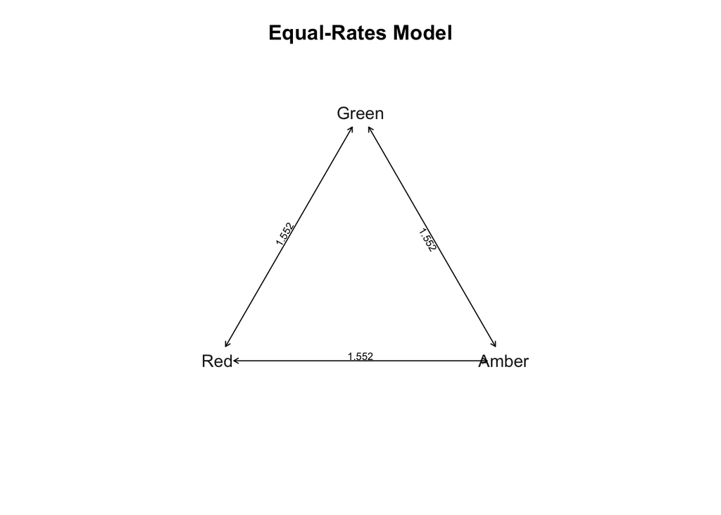

```r
plot(
  fitMkConservationER,
  main = "Equal-Rates Model"
)
```

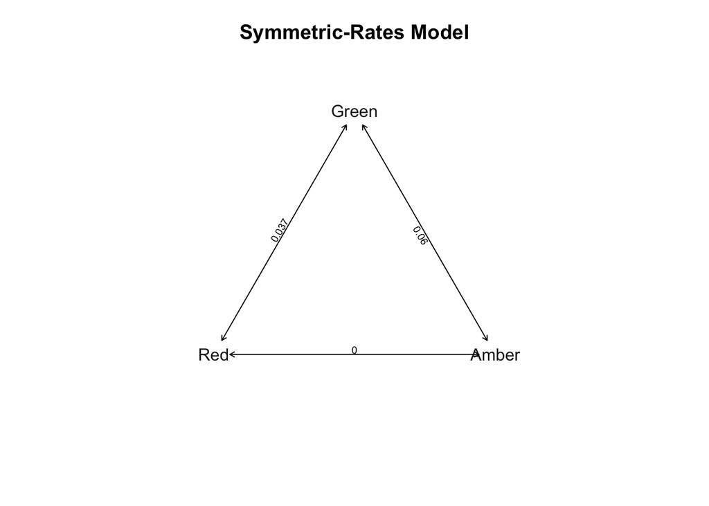

```r
plot(
  fitMkConservationSYM,
  main = "Symmetric-Rates Model"
)
```

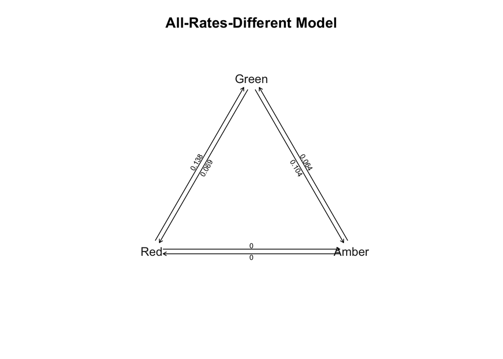

```r
plot(
  fitMkConservationARD,
  main = "All-Rates-Different Model"
)
```

# Format the state data for corHMM

This follows the same method I used in my original ancestral-state file. The state vector is converted into a two-column data frame with species names in the first column and the observed state in the second.

```r
conservationStateVector <- setNames(
  as.character(prunedConservationState),
  names(prunedConservationState)
)

# corHMM uses "/" to separate polymorphic states.
conservationStateVector <- gsub(
  "+",
  "/",
  conservationStateVector,
  fixed = TRUE
)

# gsub() can also remove names, so assign them again.
names(conservationStateVector) <- names(prunedConservationState)

conservationData <- data.frame(
  species = names(conservationStateVector),
  conservationState = unname(conservationStateVector),
  stringsAsFactors = FALSE
)

head(conservationData)
```

```
##             species conservationState
## 1     Tetrao.tetrix               Red
## 2   Lagopus.lagopus             Amber
## 3      Lagopus.muta             Green
## 4     Perdix.perdix               Red
## 5 Coturnix.coturnix               Red
## 6       Anser.anser             Amber
```

```r
nrow(conservationData)
```

```
## [1] 181
```

# Prepare the transition-rate matrix

The index matrix from the fitted ARD model identifies which transition-rate parameter belongs to each directional change. As in my original workflow, zeros are replaced by `NA`, state names are formatted for `corHMM`, and the matrix is reordered alphabetically.

```r
# Use the best-supported ER, SYM, or ARD model.
rateMat <- bestTransitionModel$index.matrix

# Get the observed state names in the same alphabetical order used by fitMk().
modelStates <- sort(
  unique(
    as.character(prunedConservationState)
  )
)

# Confirm that the number of states matches the matrix dimensions.
if (
  length(modelStates) != nrow(rateMat) ||
  length(modelStates) != ncol(rateMat)
) {
  stop(
    paste0(
      "The number of observed states does not match the dimensions ",
      "of the transition-rate matrix."
    )
  )
}

# fitMk() may return an index matrix without dimension names,
# so add the state names before formatting it for corHMM.
dimnames(rateMat) <- list(
  modelStates,
  modelStates
)

# corHMM uses NA on the diagonal of a custom index matrix.
rateMat[rateMat == 0] <- NA

# corHMM uses "/" for polymorphic state labels.
rownames(rateMat) <- gsub(
  "+",
  "/",
  rownames(rateMat),
  fixed = TRUE
)

colnames(rateMat) <- gsub(
  "+",
  "/",
  colnames(rateMat),
  fixed = TRUE
)

rateMat
```

```
##       Amber Green Red
## Amber    NA     3   5
## Green     1    NA   6
## Red       2     4  NA
```

# Run marginal ancestral-state reconstruction with corHMM

The fitted transition rates from `fitMk()` are passed into `corHMM`, along with the custom ARD rate matrix. Marginal reconstruction returns the probability of each state at every internal node while integrating over the states at the other nodes.

```r
fitMarginal <- corHMM(
  phy = birdPrunedPhy,
  data = conservationData,
  rate.mat = rateMat,
  node.states = "marginal",
  rate.cat = 1,
  p = fitMkConservationARD$rates,
  root.p = fitMkConservationARD$pi
)
```

```
## State distribution in data:
## States:  1   2   3
## Counts:  89  60  32
## Calculating likelihood from a set of fixed parameters
## Finished. Inferring ancestral states using marginal reconstruction.
```

```r
asr <- fitMarginal$states

colnames(asr) <- colnames(rateMat)
colnames(asr) <- gsub(
  "/",
  "+",
  colnames(asr),
  fixed = TRUE
)

head(asr)
```

```
##          Amber     Green       Red
## [1,] 0.5178198 0.3218064 0.1603739
## [2,] 0.4808806 0.3382491 0.1808703
## [3,] 0.3995016 0.3608139 0.2396845
## [4,] 0.2335588 0.3945817 0.3718595
## [5,] 0.1653173 0.5062464 0.3284363
## [6,] 0.2388855 0.5933078 0.1678067
```

# Plot the phylogeny with ancestral-state probabilities

The tip states are plotted as single-color pie charts. The internal nodes are plotted using the marginal state probabilities returned by `corHMM`.

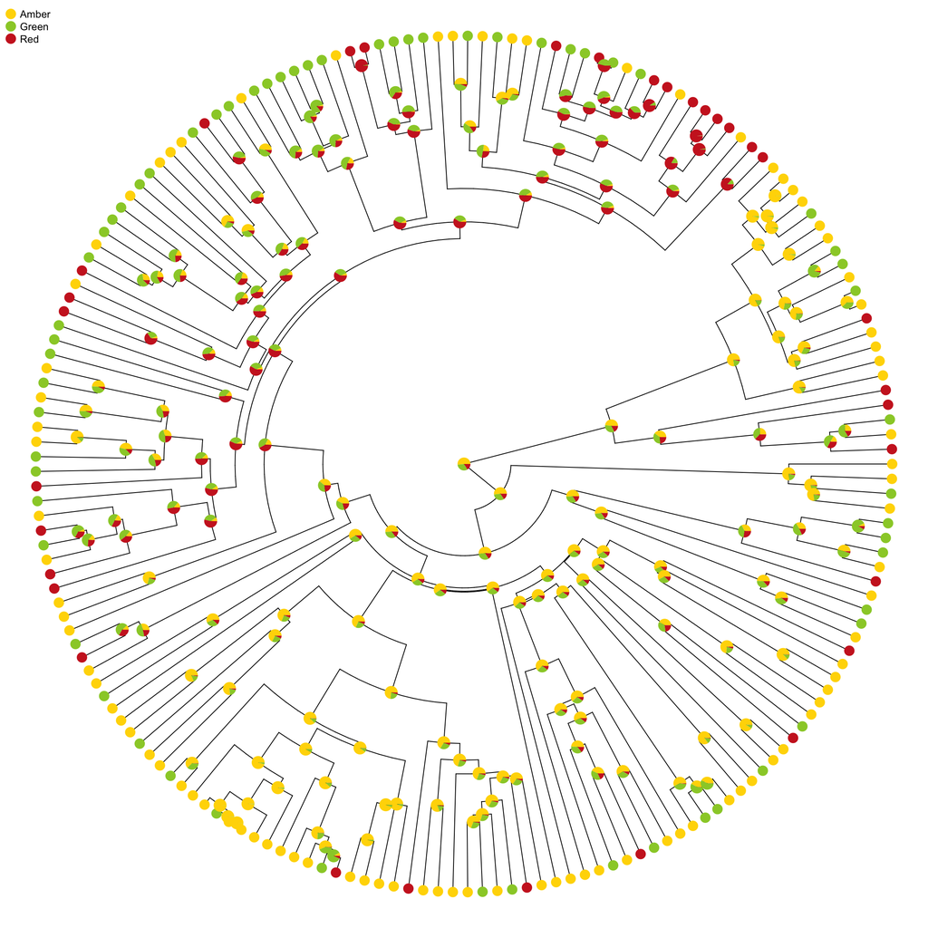

```r
plotTree(
  birdPrunedPhy,
  ftype = "off",
  lwd = 1,
  type = "fan"
)

tipStateList <- strsplit(
  setNames(
    as.character(prunedConservationState),
    names(prunedConservationState)
  ),
  "+",
  fixed = TRUE
)

stateNames <- c(
  "Amber",
  "Green",
  "Red"
)

tipPies <- matrix(
  0,
  Ntip(birdPrunedPhy),
  length(stateNames),
  dimnames = list(
    birdPrunedPhy$tip.label,
    stateNames
  )
)

for (tipIndex in seq_len(Ntip(birdPrunedPhy))) {

  tipName <- birdPrunedPhy$tip.label[tipIndex]
  observedStates <- tipStateList[[tipName]]

  tipPies[
    tipName,
    observedStates
  ] <- rep(
    1 / length(observedStates),
    length(observedStates)
  )
}

stateColors <- setNames(
  c("gold1", "olivedrab3", "firebrick3"),
  stateNames
)

par(fg = "transparent")

tiplabels(
  pie = tipPies,
  piecol = stateColors,
  cex = 0.28
)

par(fg = "black")

pieColors <- vector(
  mode = "character",
  length = ncol(asr)
)

for (stateIndex in seq_len(ncol(asr))) {

  reconstructedStates <- strsplit(
    colnames(asr)[stateIndex],
    "+",
    fixed = TRUE
  )[[1]]

  if (length(reconstructedStates) == 1) {

    pieColors[stateIndex] <- stateColors[reconstructedStates]

  } else if (length(reconstructedStates) == 2) {

    pieColors[stateIndex] <- colorRampPalette(
      stateColors[reconstructedStates]
    )(3)[2]

  } else {

    pieColors[stateIndex] <- "black"
  }
}

names(pieColors) <- colnames(asr)

par(fg = "transparent")

nodelabels(
  pie = asr,
  piecol = pieColors,
  cex = 0.35
)

par(fg = "black")

legend(
  x = "topleft",
  legend = colnames(asr),
  pt.cex = 1.8,
  pch = 16,
  cex = 0.8,
  col = pieColors,
  bty = "n"
)
```

# Interpretation

The node pie charts represent the marginal probabilities of the reconstructed conservation states. A node dominated by one color has stronger support for that state, while a node divided among colors has greater uncertainty.

The reconstruction should be interpreted as a model-based estimate rather than a direct observation of historical conservation status. Present-day conservation categories are defined using recent population and range trends, so this analysis is primarily a demonstration of the ancestral-state workflow rather than a literal biological claim about ancient threat categories.